# Forensic Botany: Plants as Silent Witnesses

## What is Forensic Botany?

- **Application of plant science to criminal and civil investigations**
  - Palynology: study of pollen and spores
  - Dendrochronology: tree-ring dating
  - Diatom analysis: aquatic forensic evidence
- **Interdisciplinary field drawing from botany, ecology, law enforcement**
- **Why Plants Matter in Forensics…**
  - *Provide evidence of movement, time, or location of crime*
  - Complement DNA, fingerprints, and traditional evidence
  - Versatile, especially in outdoor scenes or missing person cases

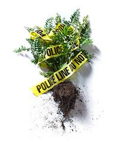

## NEW THEORY: Locard’s Exchange Principle

- **“Every contact leaves a trace” – foundational forensic concept**
- **Botanical evidence at the scene:** Plants, pollen, seeds, and soil samples found at a crime scene can be linked to a suspect if they are also found on the suspect’s clothing, shoes, or vehicle.
- **Botanical evidence on the suspect:**Conversely, plant material from the crime scene might be found on a suspect, indicating their presence at the location
- **Establishing links:** This exchange of botanical evidence can be crucial in linking a suspect to a crime scene or victim, especially when other forms of evidence are scarce.

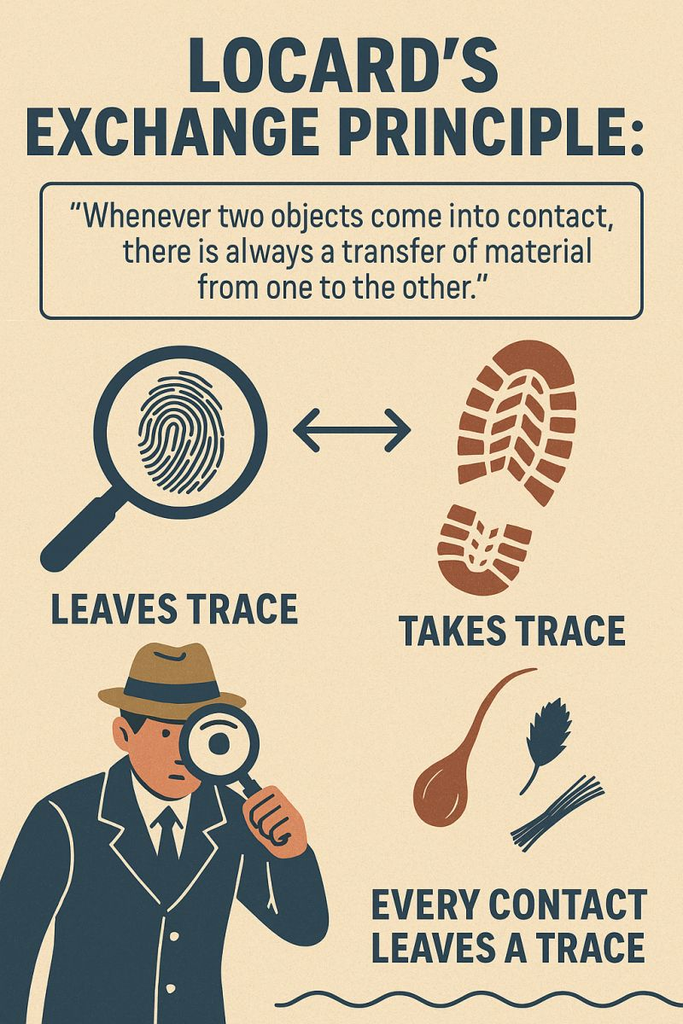

## Types of Botanical Evidence

- **Macroscopic: Leaves, twigs, seeds, fruits, bark, wood**
  - Examples: Identifying a specific type of leaf found on a suspect’s clothing, analyzing plant material in a victim’s stomach to determine time of death, or presence of a plant species to link a suspect to a crime scene.
- **Microscopic: Pollen, spores, diatoms, plant hairs (trichomes)**
  - Examples: dentifying the species of a pollen grain found on clothing or examining diatom assemblages to determine if a victim drowned in a specific body of water
- **Each type tells a different story – location, season, transfer**
- **Macroscopic and microscopic analyses often complement each other, providing a more comprehensive understanding of the plant evidence**

## Types of Botanical Evidence

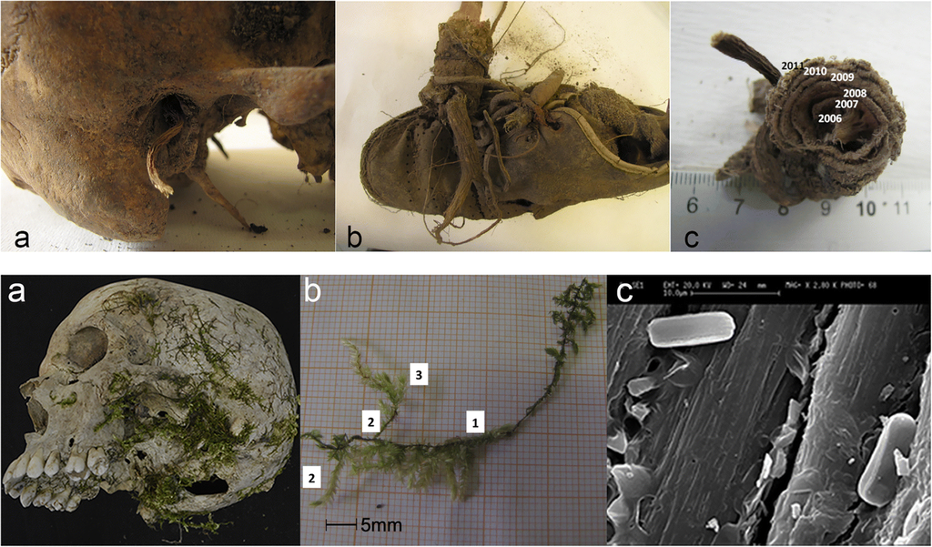

## Botanical Evidence Basics: Macroscopic

- **Look for unusual plant fragments at crime scenes - injuries (broken branches), or foreign species**
  - can links suspects with crime scenes
  - experimenting with how long leaves on a broken branch take to wilt = timing
- **Use ecology (flowering times, growth cycles etc.) of plants growing in/around body**
  - can determine timing of death (e.g. season)
- **Plant identification can be crucial for determining if poisoning has occurred**
  - stomach contents, surrounding plants
- **Seeds, burrs, and plant fragments adhere to shoes, tires, hair can reconstruct movement of people, vehicles, or bodies**

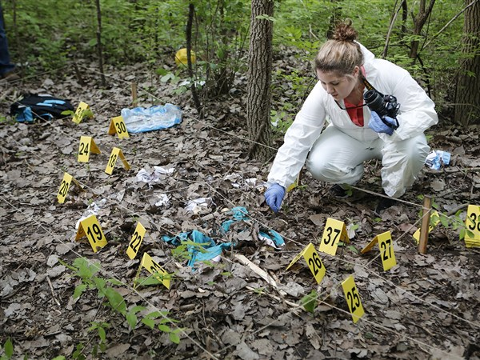

## Botanical Evidence Basics: Palynology

- **Pollen & Spores - Pollen is unique by species, geographically distinct, and resists decay**
  - can be carried by wind, water, or animals, traveling far from their source
  - individual grains of pollen from different species can look like soccer balls, sponges, padded cushions, or coffee beans
  - surfaces are covered with intricate identifiable geometric patterns
- **By examining pollen found at a crime scene or on a suspect, investigators can:**
  - potentially link individuals or objects to specific locations
  - determine the time of year a crime occurred
  - reconstruct events related to the crime

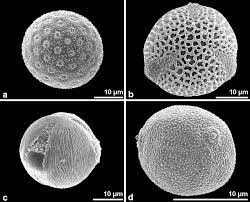

## Palynology in Drug Trafficking

- **In two different marijuana seizures in California and Texas, pollen analysis revealed a unique sagebrush pollen marker**
  - sagebrush species was known to grow in only a few isolated regions of Mexico, pinpointing the area of cultivation cultivated
- **A truck carrying cocaine was seized at the Canadian border after trying to enter from Detroit. Pollen analysis of the truck’s air filter revealed the shipment originated in California and took a circuitous route across the United States instead of a direct path to Canada**
- **Pollen analysis also has helped trace the routes of marijuana and cocaine bundles that wash up onshore along the coasts of Florida and Texas**
  - samples were loaded with fern spores, more than would be typical of an area where fern plants grow
  - there are only a few areas that have that many ferns and one of them is Fern Gully, a winding, scenic stretch of road in Jamaica

## Botanical Evidence Basics: Diatoms and Aquatic Evidence

- **Diatoms are microscopic organisms that can be inhaled with water into the lungs**
  - If the individual was alive when they entered the water, diatoms will be found in the lungs and may circulate to other organs
  - If the person was already dead, diatoms are less likely to be found
- **Comparing the types and quantities of diatoms in a victim’s body with samples from potential drowning locations can establish where the drowning occurred**
- **Diatoms can also be transferred to clothing, footwear, or other personal items, potentially linking a suspect to a crime scene or a specific water source**

[figure not shown]

## Botanical Evidence Basics: Dendrochronology & Growth Clues

- **Tree rings are used to date wood**
  - determine the age of wooden objects found at a crime scene
  - growth over time around buried objects indicates timeline of burial
  - climate records support or dispute timeline claims
- **Certain plants bloom or fruit in predictable seasonal windows**
  - presence of specific plant structures can narrow time of crime
  - ueful in matching or challenging suspect alibis

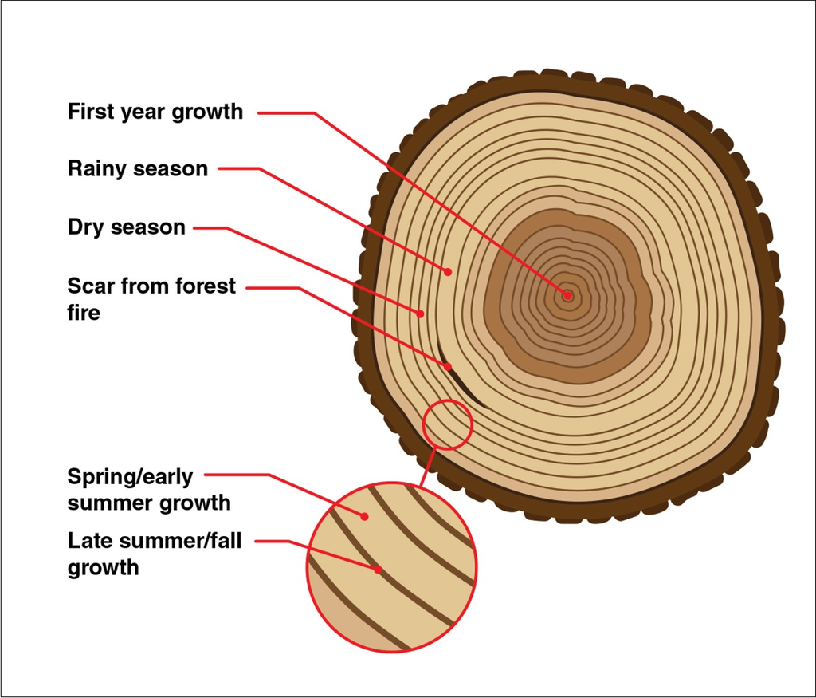

## Botanical Evidence Basics: Plant-Based Toxins and Injuries

- **Plants can cause injury or death: - Ricin from castor bean - Digitalis from foxglove - Coniine from hemlock**
  - Socrates was sentenced to drink hemlock
  - Abraham Lincoln’s mother dies from white snakeroot
  - Juan Ponce de León died after wounding from an arrow poisoned with the manchineel tree’s sap
- **Plant toxins can be used to prove a crime, such as homicide or theft, or to establish the cause of death in poisoning cases**
- **Forensic scientists use analytical techniques to identify and quantify plant toxins in biological samples (e.g., blood, urine, stomach contents)**

[figure not shown]

## Botanical Evidence Basics: Modern Technologies

- **Stable Isotope Analysis - Measuring ratios of elemental isotopes in plants reflects regional climate or water and soil composition**
  - can identify the source of illicit drugs or trace the origins of plants involved
- **Scienitsts use strontium-87 of local soils for geological fingerprinting of poached endangered Cycads in S. Africa**
  - cycads incorporate the specific isotope signature when they absorb water/nutrients

[figure not shown]

## Its Time For A………

[figure not shown]